# Estimate contrast with known alpha

Qing (Sabrina) Yu

Feb 22,2017

# Goal of the study

In this report, our goal is to check the distribution of phylogenetic contrasts with known alpha, known shift configuration and unknown shift values that are used in the bootstrap procedure in the `l1ou` package. In the last report, we used the true shift edge, true shift values, true alpha.

# Estimate shift configuration from orignal lizard data (change)

We used the lizard tree from the `phylolm` package and associated trait data on these lizard species (just the first trait, which is the first PC axis from a PCA).

This trait was analyzed to estimate the shifts in trait evolution using the function `fit_OU` from the `l1ou` package.

```r
load('eModel_2_5.RData')
shift_config=eModel$shift.configuration
shiftnode=lizard$tree$edge[shift_config,1]-n_tips
y0=eModel$intercept
truetheta = y0 + l1ou:::convert_shifts2regions(eModel$tree,
                                eModel$shift.configuration, eModel$shift.values)
truealpha=eModel$alpha
sigma2=eModel$sigma2
othernode=(1:(n_tips-1))[-shiftnode] # Other nodes: those without a true shift
```

We used this model to simulate new data using the `rTraitCont` function from the `phylolm` package. Below, `RE` is the result of the function `sqrt_OU_covariance`, which calculates the square-root of the phylogenetic covariance matrix with a recursive algorithm, which traverses the tree once. `covInverseSqrt` is the inverse square root of the phylogenetic covariance matrix, and `covSqrt` is the square-root of the phylogenetic covariance matrix. Finally, `contrast` contains the contrasts at all nodes. These matrices and contrasts were obtained using the true value of $\alpha$, the same value used to simulate the data. This is an ideal situation when $\alpha$ is known without error.

# simulation procedure

we use the same data for all scenarios: set.seed here, then save data in ytable.

```r
n_sim=100000
Y_table=matrix(nrow=n_sim, ncol=n_tips, data=NA)
set.seed(1293)
for (i in 1:n_sim) {
  Y_table[i,]  <- rTraitCont(eModel$tree, "OU", theta=truetheta,
                 alpha=truealpha,
                 sigma=sqrt(sigma2), root.value=y0)
}
colnames(Y_table)=eModel$tree$tip.label
save(Y_table, file="Y_table_2_5.RData")
```

```r
load("Y_table_2_5.RData")
len=dim(Y_table)[1]
```

# Estimation Procedure

We consider 4 scenarios for the calculation of contrasts, depending on what parameters are known (yes) or unknown (no) for the calculation of the inverse square-root of the covariance matrix.

[output not shown]

# scenario 1: all parameters known and set to their true values

use Y table, call contrasts table “contrast_table1”

```r
contrast_table1=matrix(nrow=n_sim, ncol=n_tips, data=NA)
RE = sqrt_OU_covariance(eModel$tree, alpha=truealpha,
                        root.model = eModel$l1ou.options$root.model,
                        check.order=F, check.ultrametric=F)
covInverseSqrt  <- t(RE$sqrtInvSigma)

for (i in 1:len) {
    contrast_table1[i,]  = covInverseSqrt%*%(Y_table[i,] - eModel$mu)
}
save(contrast_table1, file="allknown_contrast.RData")
```

# scenario 2: known alpha and known shift configuration, beta unknown around 3 hrs

```r
RE = sqrt_OU_covariance(lizard$tree, alpha=eModel$alpha, # assumed known here
                        root.model = "OUfixedRoot",
                        check.order=F, check.ultrametric=F)
covInverseSqrt  <- t(RE$sqrtInvSigma)

contrast_table2=matrix(nrow=len, ncol=n_tips, data=NA)
sigma_table2=rep(NA,len)
mu_table2=matrix(nrow=len, ncol=n_tips, data=NA)
shift_values2=matrix(nrow=len, ncol=length(shift_config), data=NA)
for (i in 1:len) {
  model= fit_OU(lizard$tree, Y_table[i,], shift_config,
                alpha.upper=truealpha, alpha.lower=truealpha, alpha.starting.value=truealpha)
  # the line above is to fix alpha to the known value
 sigma_table2[i] = model$sigma2
 shift_values2[i,]=model$shift.values
 mu_table2[i,]=model$mu
  contrast_table2[i,]  <-  covInverseSqrt%*%(Y_table[i,] - model$mu)
}
save(sigma_table2,file="knownalpha_sigma2.RData")
 save(contrast_table2,file="knownalpha_contrast.RData")
 save(mu_table2,file="knownalpha_mu.RData")
 save(shift_values2,file="knownalpha_shiftvalues.RData")
```

# scenario 3: known shiftconfig but unknown alpha and unknown beta

```r
contrast_table3 = matrix(nrow=len, ncol=n_tips, data=NA)
alpha_table3  = rep(NA,len)
sigma_table3 = rep(NA,len)
mu_table3 = matrix(nrow=len, ncol=n_tips, data=NA)
shift_values3 = matrix(nrow=len, ncol=length(shift_config), data=NA)
# also save sigma2 estimated values, and 8 shift values? and/or 100 mu values?
for (i in 1:len) {
  model= fit_OU(lizard$tree, Y_table[i,], shift_config)
  alpha_table3[i] = model$alpha
  sigma_table3[i] = model$sigma2
  shift_values3[i,]=model$shift.values
  mu_table3[i,]=model$mu
  RE = sqrt_OU_covariance(lizard$tree, alpha=model$alpha, # alpha estimated here
                          root.model = "OUfixedRoot",
                          check.order=F, check.ultrametric=F)
  covInverseSqrt  <- t(RE$sqrtInvSigma)
  contrast_table3[i,] <-  covInverseSqrt%*%(Y_table[i,] - model$mu)
}
save(contrast_table3,file="unknownalpha_contrast.RData")
save(alpha_table3, file="unknownalpha_alpha.RData")
save(sigma_table3,file="unknownalpha_sigma2.RData")
save(mu_table3,file="unknownalpha_mu.RData")
save(shift_values3,file="unknownalpha_shiftvalues.RData")
```

# scenario 4: unknown shift configuration, unknown alpha and unknown beta

```r
n_sim=2000 # lower because estimation is a lot slower when we have to search for the config
# use first n_sim rows of Ytable only
Y_table=Y_table[1:n_sim,]
contrast_table4=matrix(nrow=n_sim, ncol=n_tips, data=NA)
vectorOfShift <- vector(mode = "list", length = n_sim)
alpha_table4  = rep(NA,n_sim)
sigma_table4 = rep(NA,n_sim)
mu_table4 = matrix(nrow=n_sim, ncol=n_tips, data=NA)
shift_values4 = vector(mode = "list", length = n_sim)

for (i in 1:n_sim) {
  model= estimate_shift_configuration(lizard$tree, Y_table[i,])
  vectorOfShift[[i]] =model$shift.configuration
  alpha_table4[i] = model$alpha
  sigma_table4[i] = model$sigma2
  shift_values4[[i]]=model$shift.values
  mu_table4[i,]=model$mu
  RE = sqrt_OU_covariance(lizard$tree ,alpha=model$alpha,
                          root.model = "OUfixedRoot",
                          check.order=FALSE, check.ultrametric=FALSE)
  covInverseSqrt  <- t(RE$sqrtInvSigma)
  contrast_table4[i,] <-  covInverseSqrt%*%(Y_table[i,] - model$mu)
}
save(contrast_table4,file="unknownconfig_contrast.RData")
save(alpha_table4, file="unknownconfig_alpha.RData")
save(sigma_table4,file="unknownconfig_sigma2.RData")
save(mu_table4,file="unknownconfig_mu.RData")
save(shift_values4,file="unknownconfig_shiftvalues.RData")
save(vectorOfShift,file="unknownconfig_shifts.RData")
```

# Results: visualizations of contrast distributions

Function to calculate the variance of contrasts assuming mean 0.

```r
ss=function(x){
  sum(x^2)/length(x)
}
```

### all parameters known and set to their true values

```r
 load("~/R/traitevoOUshift/contrast_cases/allknown_contrast.RData")
head(colMeans(contrast_table1))
```

```
## [1]  0.0002936259  0.0005437081 -0.0011580854 -0.0014622974  0.0013248416
## [6] -0.0001489877
```

```r
max(abs(colMeans(contrast_table1)))
```

```
## [1] 0.001822459
```

```r
round(colMeans(contrast_table1),5)
```

```
##   [1]  0.00029  0.00054 -0.00116 -0.00146  0.00132 -0.00015 -0.00011
##   [8]  0.00032  0.00109 -0.00039 -0.00069 -0.00036 -0.00044  0.00150
##  [15]  0.00060  0.00015 -0.00048  0.00109 -0.00112  0.00032 -0.00021
##  [22]  0.00124  0.00055  0.00019 -0.00014  0.00166 -0.00067 -0.00171
##  [29] -0.00113  0.00035  0.00039 -0.00005  0.00079 -0.00073 -0.00058
##  [36]  0.00024  0.00016  0.00078  0.00136 -0.00034 -0.00106 -0.00081
##  [43]  0.00090  0.00036 -0.00182 -0.00073 -0.00113  0.00001  0.00079
##  [50] -0.00036  0.00092 -0.00088 -0.00041 -0.00033  0.00038 -0.00038
##  [57] -0.00080 -0.00008  0.00013 -0.00045  0.00070 -0.00048  0.00063
##  [64] -0.00121 -0.00094  0.00022 -0.00029 -0.00129 -0.00058  0.00018
##  [71]  0.00028 -0.00132 -0.00082  0.00006 -0.00080 -0.00120  0.00040
##  [78]  0.00006  0.00045  0.00045 -0.00039  0.00005  0.00058  0.00101
##  [85]  0.00033  0.00005  0.00086  0.00040 -0.00028  0.00032 -0.00049
##  [92]  0.00142 -0.00022 -0.00119  0.00075  0.00029 -0.00035 -0.00123
##  [99] -0.00040 -0.00026
```

```r
convar=apply(contrast_table1,2,ss)
round(convar,3)
```

```
##   [1] 0.062 0.063 0.062 0.062 0.062 0.062 0.063 0.062 0.062 0.062 0.062
##  [12] 0.062 0.063 0.062 0.063 0.063 0.063 0.062 0.062 0.063 0.062 0.063
##  [23] 0.063 0.062 0.062 0.063 0.062 0.062 0.062 0.063 0.062 0.062 0.063
##  [34] 0.063 0.063 0.063 0.063 0.063 0.063 0.063 0.063 0.062 0.062 0.062
##  [45] 0.062 0.062 0.062 0.062 0.063 0.062 0.063 0.063 0.062 0.062 0.063
##  [56] 0.062 0.062 0.062 0.062 0.063 0.063 0.063 0.062 0.063 0.063 0.063
##  [67] 0.062 0.063 0.062 0.063 0.063 0.063 0.063 0.062 0.062 0.062 0.063
##  [78] 0.062 0.063 0.063 0.062 0.063 0.063 0.063 0.063 0.063 0.062 0.062
##  [89] 0.063 0.062 0.062 0.063 0.063 0.062 0.062 0.063 0.062 0.063 0.062
## [100] 0.062
```

```r
mean(convar)
```

```
## [1] 0.06249321
```

```r
sigma2
```

```
## [1] 0.06251866
```

```r
load("~/R/traitevoOUshift/contrast_cases/knownalpha_contrast.RData")
load("~/R/traitevoOUshift/contrast_cases/knownalpha_sigma2.RData")
load("~/R/traitevoOUshift/contrast_cases/knownalpha_shiftvalues.RData")
load("~/R/traitevoOUshift/contrast_cases/knownalpha_mu.RData")
head(colMeans(contrast_table2))
```

```
## [1]  0.0003875738  0.0007176718 -0.0015286240 -0.0019301709  0.0017487351
## [6] -0.0001966575
```

```r
max(abs(colMeans(contrast_table2)))
```

```
## [1] 0.00240557
```

```r
round(colMeans(contrast_table2),5)
```

```
##   [1]  0.00039  0.00072 -0.00153 -0.00193  0.00175 -0.00020  0.00018
##   [8]  0.00029  0.00144 -0.00052 -0.00091 -0.00047 -0.00052  0.00198
##  [15]  0.00085  0.00022 -0.00063  0.00143 -0.00148  0.00043 -0.00027
##  [22]  0.00164  0.00073  0.00025 -0.00019  0.00219 -0.00088 -0.00006
##  [29] -0.00150  0.00046  0.00052 -0.00006  0.00105 -0.00096 -0.00077
##  [36]  0.00032 -0.00003 -0.00010  0.00079 -0.00101 -0.00140 -0.00107
##  [43]  0.00119  0.00047 -0.00241 -0.00096 -0.00150  0.00002  0.00063
##  [50] -0.00048  0.00122 -0.00116 -0.00055 -0.00044  0.00050 -0.00050
##  [57] -0.00105 -0.00026  0.00017 -0.00059  0.00093 -0.00063  0.00083
##  [64] -0.00159 -0.00133  0.00095 -0.00038 -0.00171 -0.00077  0.00023
##  [71]  0.00038 -0.00174 -0.00108  0.00008 -0.00105 -0.00158  0.00053
##  [78]  0.00007  0.00060  0.00060 -0.00052  0.00004  0.00078  0.00133
##  [85]  0.00043  0.00006  0.00113  0.00053 -0.00037  0.00043 -0.00065
##  [92]  0.00188 -0.00029 -0.00157  0.00099  0.00038 -0.00046 -0.00132
##  [99] -0.00062  0.00000
```

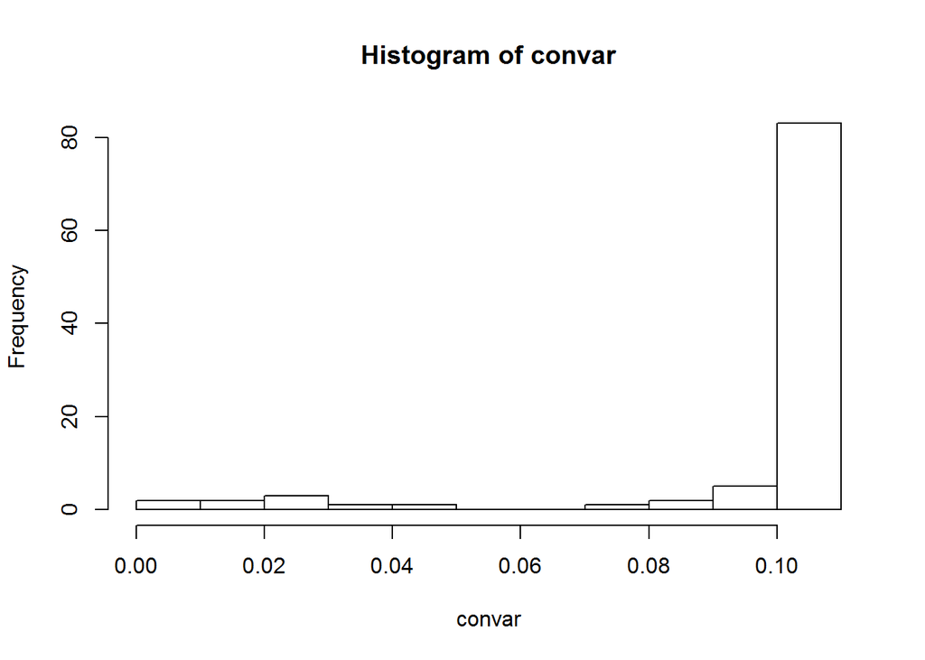

```r
convar=apply(contrast_table2,2,ss)
hist(convar)
```

```r
round(convar,3)
```

```
##   [1] 0.108 0.109 0.109 0.108 0.109 0.109 0.021 0.096 0.108 0.109 0.108
##  [12] 0.108 0.107 0.109 0.107 0.012 0.109 0.109 0.109 0.109 0.109 0.109
##  [23] 0.109 0.109 0.109 0.109 0.108 0.023 0.109 0.109 0.109 0.109 0.110
##  [34] 0.109 0.109 0.109 0.007 0.078 0.049 0.090 0.109 0.108 0.109 0.108
##  [45] 0.109 0.108 0.109 0.109 0.020 0.108 0.109 0.109 0.109 0.108 0.109
##  [56] 0.108 0.109 0.097 0.032 0.092 0.109 0.109 0.100 0.107 0.102 0.086
##  [67] 0.109 0.109 0.109 0.109 0.110 0.109 0.109 0.109 0.109 0.108 0.110
##  [78] 0.109 0.110 0.109 0.109 0.024 0.092 0.109 0.109 0.110 0.109 0.109
##  [89] 0.109 0.108 0.109 0.109 0.109 0.109 0.108 0.104 0.108 0.101 0.093
## [100] 0.000
```

```r
mean(convar)
```

```
## [1] 0.09907413
```

```r
sigma2
```

```
## [1] 0.06251866
```

```r
#Check which contrasts are extremely different from 0
```

### known shiftconfig but unknown alpha and unknown beta

```r
load("~/R/traitevoOUshift/contrast_cases/unknownalpha_contrast.RData")
load("~/R/traitevoOUshift/contrast_cases/unknownalpha_sigma2.RData")
load("~/R/traitevoOUshift/contrast_cases/unknownalpha_shiftvalues.RData")
load("~/R/traitevoOUshift/contrast_cases/unknownalpha_mu.RData")
load("~/R/traitevoOUshift/contrast_cases/unknownalpha_alpha.RData")
head(colMeans(contrast_table3))
```

```
## [1] -435.33573  -29.07052 -242.57118 -166.72133  141.71022  562.82701
```

```r
max(abs(colMeans(contrast_table3)))
```

```
## [1] 615.4257
```

```r
round(colMeans(contrast_table3),5)
```

```
##   [1] -435.33573  -29.07052 -242.57118 -166.72133  141.71022  562.82701
##   [7]   14.05004   40.45147  -82.38507  320.31221   92.04545  128.37062
##  [13] -377.94805  375.98009  148.54985 -120.72063   18.80753 -354.87895
##  [19]  109.04844  504.74554 -252.94401  -29.91306  374.84592  -92.05746
##  [25]  263.31992 -107.94309  565.27666   38.80174  -68.72003   82.38918
##  [31]  256.27335 -136.78367  545.80337  -88.89007  342.00907 -260.66234
##  [37]   24.15799   74.59259 -247.35483  198.49671   83.47696 -301.37969
##  [43] -223.79797 -221.50678 -131.07286  500.21439 -265.38789  -30.80378
##  [49]  259.73941  -61.56101  102.25335  -54.15544 -524.22334  197.16218
##  [55] -360.48733 -209.07820 -497.46135 -322.04972 -184.13483  520.72212
##  [61]  165.63997 -210.58324 -318.06912  -76.07058 -549.78526   -6.96424
##  [67] -177.92548  -88.30571  -73.46946 -381.02474 -150.92119 -301.89538
##  [73] -438.38438   11.70052  491.95391  -58.53737  -55.62790  615.42570
##  [79]   -1.92918 -132.01984  -10.13931   16.47799    6.58871   99.97222
##  [85] -215.34818  203.40387   87.19344  190.19399  321.77901 -551.88211
##  [91]   73.45004    5.03788   54.63554 -149.61049  138.67420  -81.88864
##  [97]  122.81529 -293.52383  324.31131    0.00000
```

```r
convar=apply(contrast_table3,2,ss)
round(convar,3)
```

```
##   [1]  7516741565  7826734489 10669453442  7257865671  9067491492
##   [6] 10525946447  2196089579 10362188841  8472689067  7148347533
##  [11]  8394591755  7481698648 11126587997 10160257891 11178295807
##  [16]  1413208061 10410668611  8153910042  7951511633  8770949624
##  [21]  8922809921  9713244154  8598932688  9708882810  7850695925
##  [26]  8352009950  8511643817  2366058801  7472384226  7111999151
##  [31]  9260616486  8856508309  8252239533  8096267056 10312791310
##  [36] 11047426361   917157910  8744081595  5120091926 10454881235
##  [41]  7794135916  7406735221  8552559892  8006243436  8470585074
##  [46]  8710957162  8265722764  9608027217  1941244466  8408566546
##  [51]  6942664382  8685318022  8090767214  8606373541  9459979349
##  [56] 10244261845  9527379568 10761359562  2604764232  8538991199
##  [61]  8336739331  9536626781 10385538911 12185132938 12880704185
##  [66] 10765629395  8041767964  8757926131  8589420006  9068628562
##  [71]  9524642192  8983108523  8397758270  9980186701  9744983489
##  [76]  8024679528  9666630099 11588838399  9553183008  7574635964
##  [81]  8651895269  2224914180  9153400486  8155781904  8613482791
##  [86]  8799131480  7952922867  7839654629  8821026412  9400475489
##  [91] 11203900332  8378897948  8349886079  9947600722 12142508382
##  [96] 12638845047 11185915620 12599994177 10199223462           0
```

```r
mean(convar)
```

```
## [1] 8542288056
```

```r
sigma2
```

```
## [1] 0.06251866
```

```r
#Check which contrasts are extremely different from 0
```

```r
load("~/R/traitevoOUshift/contrast_cases/unknownconfig_alpha.RData")
load("~/R/traitevoOUshift/contrast_cases/unknownconfig_shifts.RData")
load("~/R/traitevoOUshift/contrast_cases/unknownconfig_sigma2.RData")
load("~/R/traitevoOUshift/contrast_cases/unknownconfig_mu.RData")
load("~/R/traitevoOUshift/contrast_cases/unknownconfig_shiftvalues.RData")
load("~/R/traitevoOUshift/contrast_cases/unknownconfig_contrast.RData")
#mean of contrasts are extremely different from zero
head(colMeans(contrast_table4))
```

```
## [1] -12233.1720 -11989.2070   -266.8603   7862.5390   -543.3527  -9526.8175
```

```r
max(abs(colMeans(contrast_table4)))
```

```
## [1] 179941.5
```

```r
colMeans(contrast_table4)
```

```
##   [1] -1.223317e+04 -1.198921e+04 -2.668603e+02  7.862539e+03 -5.433527e+02
##   [6] -9.526817e+03  1.799415e+05 -6.582780e+04  6.629157e+03  7.016446e+03
##  [11]  5.476064e+03 -1.484576e+03  3.692414e+04  2.735268e+03  2.193239e+04
##  [16]  4.195634e+03  4.524137e+03 -3.720164e+03  5.575029e+03 -5.725860e+03
##  [21] -1.402449e+03  4.116775e+03  3.287586e+03  9.233476e+02  4.178721e+03
##  [26]  4.843030e+02  3.010432e+03 -1.446708e+05 -2.500177e+03 -7.819262e+03
##  [31] -7.299318e+03 -2.261691e+03 -5.444105e+03 -1.862386e+03  6.686872e+03
##  [36]  8.605287e+03  1.796138e+05  2.432312e+04 -6.269494e+04 -3.303814e+04
##  [41]  3.761259e+03 -3.685559e+03 -4.107436e+03 -9.789576e+02  1.231673e+03
##  [46]  8.990762e+03  2.292866e+03 -5.163241e+02  1.224122e+05 -1.326445e+04
##  [51]  6.673279e+03 -1.515252e+04  9.195990e+01  7.351193e+03  2.036051e+03
##  [56] -2.551099e+03  8.654137e+03  4.892189e+04  2.553842e+04  7.142839e+03
##  [61]  2.882577e+03  6.273590e+03 -2.165679e+02  1.144843e+04  2.271156e+04
##  [66]  2.080977e+04  6.201610e+03 -9.692806e+03 -1.019771e+04  3.806060e+03
##  [71] -2.159151e+02  2.081907e+02 -7.013719e+03  6.950515e+03 -5.352894e+03
##  [76] -1.929034e+03 -3.619018e+03 -2.872799e+03 -8.116352e+03 -6.414344e+02
##  [81]  7.712281e+03  1.277367e+05 -5.763026e+04 -1.505753e+04  8.680179e+03
##  [86]  6.802785e+03  8.623402e+03  5.101654e+03  4.888703e+03  1.755781e+03
##  [91]  6.474588e+03  2.950678e+03  1.964006e+03 -1.740514e+04  2.132995e+03
##  [96]  2.642430e+04 -7.094353e+03  1.132115e+04  6.070688e+03  2.080932e-06
```

```r
convar=apply(contrast_table4,2,ss)
convar
```

```
##   [1] 8.719938e+10 8.435614e+10 7.831016e+10 8.130531e+10 6.569620e+10
##   [6] 8.209879e+10 5.353343e+11 1.466712e+11 9.418315e+10 7.243808e+10
##  [11] 9.004632e+10 9.183239e+10 9.334968e+10 6.716216e+10 8.039053e+10
##  [16] 2.787307e+10 9.228044e+10 8.912861e+10 9.303234e+10 9.877756e+10
##  [21] 8.253520e+10 7.158843e+10 8.842589e+10 7.179844e+10 8.281029e+10
##  [26] 6.449683e+10 8.734540e+10 5.023446e+11 6.684465e+10 8.149539e+10
##  [31] 7.987839e+10 7.070469e+10 7.176086e+10 7.589890e+10 8.129080e+10
##  [36] 8.205387e+10 6.211108e+11 8.734093e+10 1.661857e+11 1.248872e+11
##  [41] 8.133412e+10 9.177579e+10 7.255822e+10 8.729743e+10 8.728423e+10
##  [46] 8.281221e+10 7.075073e+10 7.432639e+10 3.954195e+11 6.694170e+10
##  [51] 9.222817e+10 8.914654e+10 7.944590e+10 7.213047e+10 8.079847e+10
##  [56] 8.269042e+10 8.242199e+10 1.245974e+11 9.378473e+10 7.624968e+10
##  [61] 9.041754e+10 8.387184e+10 8.650226e+10 9.713187e+10 1.069812e+11
##  [66] 9.906223e+10 6.615620e+10 8.411888e+10 9.359826e+10 9.129276e+10
##  [71] 8.337129e+10 6.996485e+10 6.620917e+10 8.699735e+10 9.483914e+10
##  [76] 7.950326e+10 7.533979e+10 6.462053e+10 9.230254e+10 9.049161e+10
##  [81] 8.449242e+10 3.766348e+11 1.289296e+11 8.738868e+10 8.258377e+10
##  [86] 7.665530e+10 1.020009e+11 8.087053e+10 6.925699e+10 9.788258e+10
##  [91] 8.943658e+10 1.007313e+11 7.382488e+10 8.464578e+10 8.057739e+10
##  [96] 8.700703e+10 7.817168e+10 9.012225e+10 6.629676e+10 7.028775e-10
```

```r
mean(convar)
```

```
## [1] 104365389098
```

```r
head(vectorOfShift)
```

```
## [[1]]
## [1]  55  98  14 118 164  77  32
##
## [[2]]
## [1]  77  32  14 118
##
## [[3]]
## [1]  55  32 118 164  98  77  14
##
## [[4]]
## [1]  14 164  74 118  77  55  32
##
## [[5]]
## [1] 118  77  32  98  74  14  55 164
##
## [[6]]
## [1]  74 164  55 118  98  77  32
```

```r
#Shifts that occur the most often
vectorOfShift=unlist(vectorOfShift, recursive = TRUE, use.names = F)
as.data.frame(table(vectorOfShift))
```

```
##    vectorOfShift Freq
## 1              1    1
## 2             13    1
## 3             14 1542
## 4             15    3
## 5             21    1
## 6             23    1
## 7             25    1
## 8             26    1
## 9             27    2
## 10            29    1
## 11            32 1996
## 12            41    1
## 13            43    1
## 14            52    4
```

[output cut: 54 more lines]

The shifts being detected most often are: 32,77,118,164,98,14,55,74 which are exactly corresponding to the shift configuration 55, 98, 118, 74, 14, 77, 32, 164of the true model.